# Genomic selection basics

M Perez-Enciso

miguel.perez@uab.es

October, 2018

### Modified from G. de los Campos (gdeloscampos@epi.msu.edu).

```r
#If you don't have installed the BGLR or glmnet packages, please run the following lines
#install.packages("BGLR",repos="https://cran.r-project.org/")
#install.packages("glmnet",repos="https://cran.r-project.org/")
rm(list=ls())
library(BGLR)
library(glmnet)
```

The wheat data are described in https://rdrr.io/cran/BGLR/man/wheat.html

```r
data(wheat)
# marker data
X=wheat.X
# phenotypes
Y=wheat.Y
# N obs
N=nrow(X)
# N markers
p = ncol(X)
# phenotype
y = Y[,2]
```

## Partition

Prediction methods are evaluated by partitioning the whole dataset in two groups. The training partition is used for adjusting model parameters. Next, the observed and predicted phenotypes with the TRN adjusted model are compared.

```r
# training set comprises 80% of data
trn<-sample(1:N, size=N*0.8, replace=FALSE)
XTRN<-X[trn,] ; yTRN<-y[trn];
# testing test
XTST<-X[-trn,] ; yTST<-y[-trn]
```

# GLMNET package

‘GLMNET (https://web.stanford.edu/~hastie/glmnet/glmnet_alpha.html) is a package that fits a generalized linear model via penalized maximum likelihood. The regularization path is computed for the lasso or elasticnet penalty at a grid of values for the regularization parameter lambda. The algorithm is extremely fast, and can exploit sparsity in the input matrix x. It fits linear, logistic and multinomial, poisson, and Cox regression models. A variety of predictions can be made from the fitted models. It can also fit multi-response linear regression’.

```r
# alpha 0 gives Ridge Regression
 fmRR=glmnet(y=yTRN,x=XTRN,lambda=.1, alpha=0)

# alpha 1 gives Lassso
 fmL=glmnet(y=yTRN,x=XTRN,lambda=.1, alpha=1)

# alpha between 0 and 1 gives elastic net
 fmEN=glmnet(y=yTRN,x=XTRN,lambda=.1, alpha=0.5)

 yHatRR = fmRR$a0 + XTST%*%fmRR$beta[,1]
 yHatL = fmL$a0 + XTST%*%fmL$beta[,1]
 yHatEN = fmEN$a0 + XTST%*%fmEN$beta[,1]

 cor(yHatRR,yTST)
```

```
##           [,1]
## [1,] 0.4227332
```

```r
 cor(yHatL,yTST)
```

```
##           [,1]
## [1,] 0.3879095
```

```r
 cor(yHatEN,yTST)
```

```
##           [,1]
## [1,] 0.4783454
```

EXECRCISE: plot corr for a grid of alpha values

# BGLR package

‘The BGLR Package (Perez-Rodriguez & de los Campos, 2014) implements a variety of shrinkage and variable selection regression procedures’.

### Fits the whole dataset, Bayesian Ridge Regression (GBLUP)

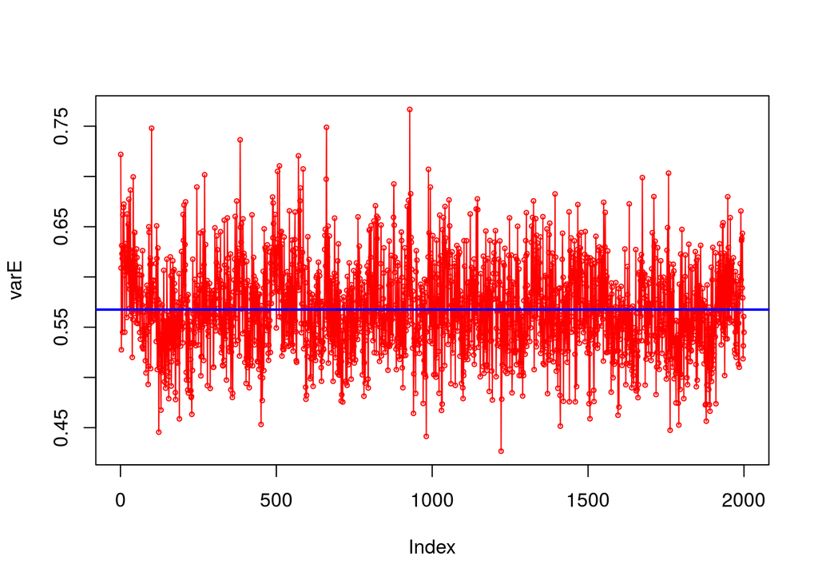

```r
ETA<-list(list(X=X,model="BRR"))
fm<-BGLR(y=y,ETA=ETA,nIter=10000,burnIn=2000,verbose=FALSE)

# trace plot of the residual variance
varE<- scan("varE.dat")
plot(varE,type="o",col=2,cex=.5)
abline(h=fm$varE,col=4, lwd=2)
```

## Assess predictive accuracy with different models using BGLR

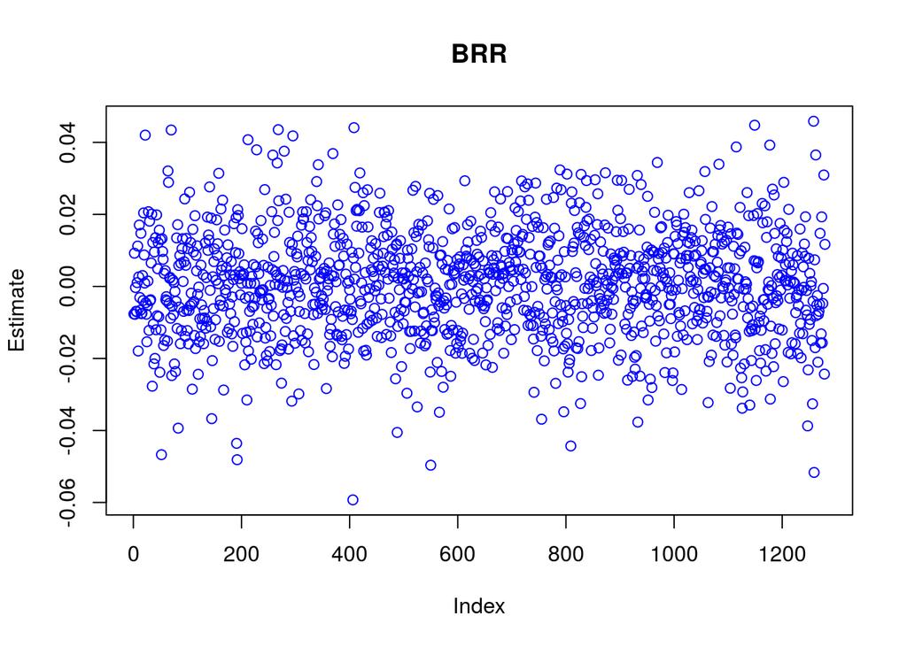

```r
### removes phenotypes from TST partition
yNA = y
yNA[-trn] = NA

### ridge
ETA<-list(list(X=X,model="BRR"))
fmRR<-BGLR(y=yNA,ETA=ETA,nIter=5000,burnIn=2000,verbose=FALSE)

### BayesA(Scaled-t prior)
ETA<-list(list(X=X,model="BayesA"))
fmBA<-BGLR(y=yNA,ETA=ETA,nIter=5000,burnIn=2000,verbose=FALSE)

### BayesB (point of mass at zero + scaled-t slab)
ETA<-list(list(X=X,model="BayesB"))
fmBB<-BGLR(y=yNA,ETA=ETA,nIter=5000,burnIn=2000,verbose=FALSE)

## plots of estimates
plot(fmRR$ETA[[1]]$b,col=4,ylab='Estimate',main='BRR')
```

```r
### corr between predicted and observed
cor(fmRR$yHat[-trn], y[-trn])
```

```
## [1] 0.5687684
```

```r
cor(fmBA$yHat[-trn], y[-trn])
```

```
## [1] 0.5656368
```

```r
cor(fmBB$yHat[-trn], y[-trn])
```

```
## [1] 0.5731331
```

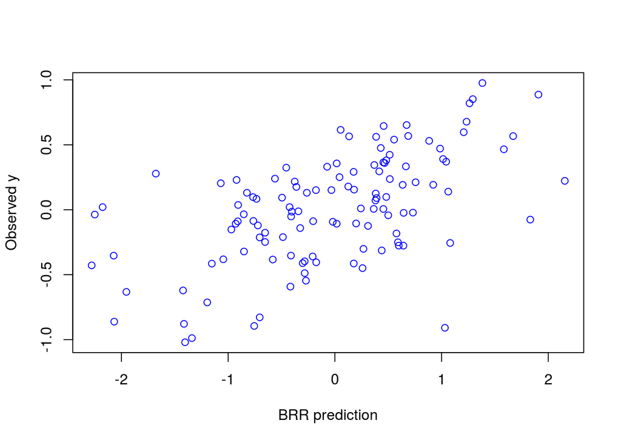

```r
plot(y[-trn], fmRR$yHat[-trn],col=4,ylab='Observed y',xlab='BRR prediction')
```

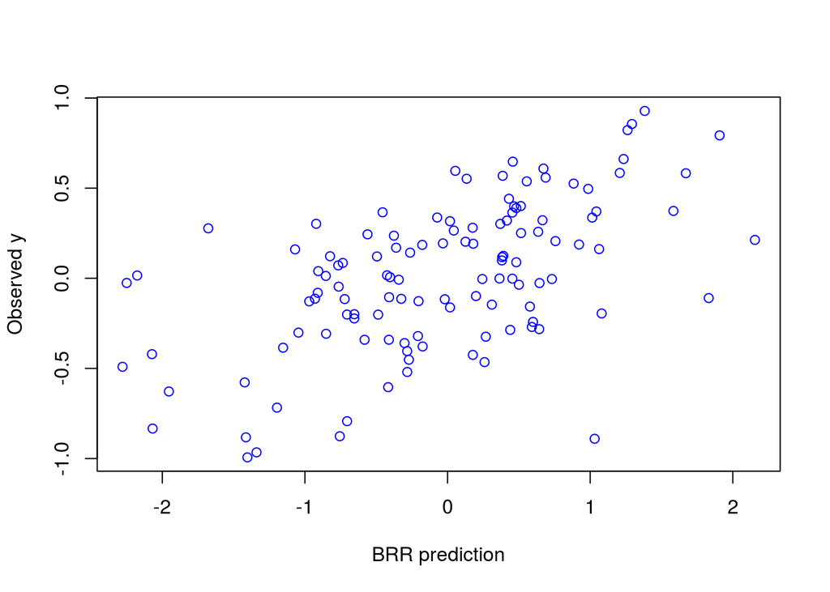

```r
plot(y[-trn], fmBA$yHat[-trn],col=4,ylab='Observed y',xlab='BRR prediction')
```

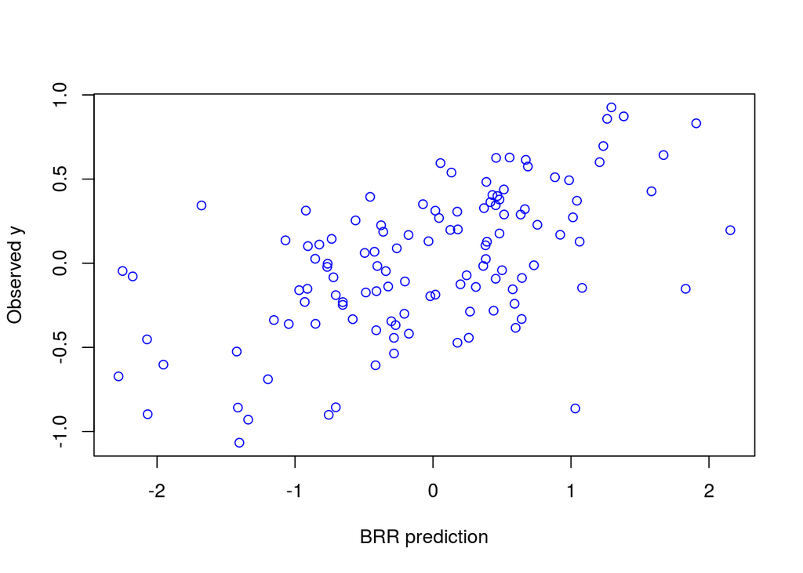

```r
plot(y[-trn], fmBB$yHat[-trn],col=4,ylab='Observed y',xlab='BRR prediction')
```

# GBLUP

### requires GRM of all individuals

```r
## GRM
G<-tcrossprod(scale(X,center=T,scale=T))
G<-G/mean(diag(G))
diag(G) = diag(G)*1.05
EVD<-eigen(G)
PC<-EVD$vectors%*%diag(sqrt(EVD$values))
ETA=list(list(X=PC,model='BRR'))

fmGB<-BGLR(y=yNA,ETA=ETA,nIter=5000,burnIn=2000,verbose=F)

### corr between predicted and observed
cor(fmGB$yHat[-trn], y[-trn])
```

```
## [1] 0.5638952
```

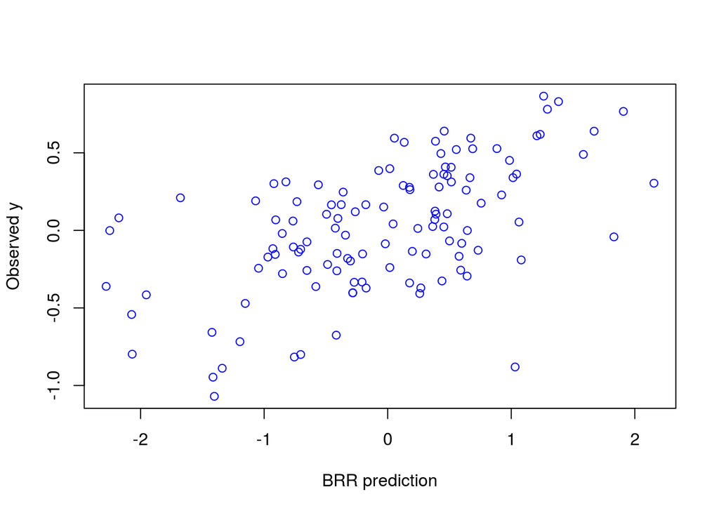

```r
plot(y[-trn], fmGB$yHat[-trn],col=4,ylab='Observed y',xlab='BRR prediction')
```

Note that all methods result in similar accuracies

# Single step

### inverse of genotyped individuals GRM